# Version control: Remote repositories on GitHub

Week 5 – Lecture B

Author

Affiliations

Jelmer Poelstra

[CFAES Bioinformatics Core, Ohio State University](https://go.osu.edu/bioinformatics-core)

[Dept. of Plant Pathology, Ohio State University](https://plantpath.osu.edu)

Presented on

September 23, 2026

Last modified

August 13, 2026

## 1 Introduction

### 1.1 Overview & context

In the previous lecture, you learned how to create and maintain version control repositories with Git. One of the advantages of doing so is the ease with which you can then share your code and other relevant files – here, you’ll learn to do so with GitHub.

In other words, we will cover how can put your local repositories online at GitHub, and how to keep local and online (“remote”) repositories in sync.

### 1.2 Learning goals

In this lecture, you will learn to:

- Create and explore version control repositories on the GitHub website
- Set up GitHub authentication to connect a local/OSC Git repo to its online counterpart on GitHub
- How to keep your local and online (remote) repositories in sync

### 1.3 Getting ready

#### Start a VS Code session

Start a VS Code session like you’ve done before.

**Click here to see the instructions**

1. Log in to OSC’s OnDemand portal at https://ondemand.osc.edu
2. In the blue top bar, select `Interactive Apps` and near the bottom, click `Code Server`
3. Fill out the form as follows:
   - **Cluster**: `pitzer`
   - **Account**: `PAS3493`
   - **Number of hours**: `2`
   - **Working Directory**: `/fs/ess/PAS3493/people/<username>` (replace `<username>` with your user name)
   - **App Code Server version**: `4.8.3`
4. Click `Launch`
5. Click the `Connect to VS Code` button once it appears
6. In VS Code, open a terminal by clicking => `Terminal` => `New Terminal` [^1]
7. Check that your are in `/fs/ess/PAS3493/people/$USER` by typing `pwd` in the terminal.  
   *(Recall that `$USER` is a variable that represents your username.* *If you’re not in that dir, it may be listed under `Recents` in the* *`Get Started` document – if so, click on that entry.* *Otherwise, click `File` > `Open Folder` and type/select* *`/fs/ess/PAS3493/people/$USER`.)*

#### Open a Markdown file for notes

Like before, I recommend that you create and open a Markdown file to keep notes:

1. Click => `File` => `New File`.
2. Save the file inside `/fs/ess/PAS3493/people/$USER/week04`, e.g. as `lectureB.md`.

#### Change your working dir

```bash
cd week04/originspecies
```

## 2 Remote repositories

You have used version control to create a local Git repository for the mock `originspecies` project. The next step is to put this repo online. Generally, sharing Git repositories online allows you to:

- Share your work (e.g. alongside a publication) and/or
- Have an online backup and/or
- Collaborate with others[^2].

We will use the **GitHub website** as the place to host our online repositories. Online counterparts of local repositories are usually referred to as “remote repositories” or simply “**remotes**”.

Using remote repositories will mean adding a couple of Git commands to our toolbox:

- **`git remote`** to add and manage connections to remotes.
- **`git push`** to upload (“push”) changes from local to remote.
- **`git pull`** to download (“pull”) changes from remote to local.

But we will need to start with some one-time setup to enable GitHub authentication.

### 2.1 One-time setup: GitHub authentication

In order to link your local Git repositories to their online counterparts on GitHub, you need to set up GitHub authentication. There are two options for this (see below) – we will use `SSH` access with an SSH key.

1. Use the `ssh-keygen` command to generate a public-private SSH key pair — in the command below, replace `your_email@example.com` with the email address you used to sign up for a GitHub account:

   ```bash
   ssh-keygen -t ed25519 -C "your_email@example.com"
   ```

2. You’ll be asked three questions, and for all three, you can accept the default simply by pressing `Enter`:

   ```bash
   # Enter file in which to save the key (<default path>):
   # Enter passphrase (empty for no passphrase):
   # Enter same passphrase again:
   ```

   ```
   Generating public/private ed25519 key pair.
   Enter file in which to save the key (/users/PAS0471/jelmer/.ssh/id_ed25519):
   Enter passphrase (empty for no passphrase):
   Enter same passphrase again:
   Your identification has been saved in /users/PAS0471/jelmer/.ssh/id_ed25519.
   Your public key has been saved in /users/PAS0471/jelmer/.ssh/id_ed25519.pub.
   The key fingerprint is:
   SHA256:KO73cE18HFC/aHKIXR7nf9Fk4++CiIw6GTk7ffG+p2c your_email@example.com
   The key's randomart image is:
   +--[ED25519 256]--+
   |          ...    |
   |           . .   |
   |            + o.o|
   |       . + = *.+o|
   |    ... S * B oo.|
   |   .+.  .o =   .o|
   |    .*.o.+.. .  +|
   |   .= +o+ o E ...|
   |    o= o..+*   ..|
   +----[SHA256]-----+
   ```

3. Now, you have a file `~/.ssh/id_ed25519.pub`, which is your **public key**. To enable authentication, you will put this public SSH key (which interacts with your private SSH key) on GitHub. Print the file with your public SSH key to your screen using `cat`:

   ```bash
   cat ~/.ssh/id_ed25519.pub
   ```

   ```
   ssh-ed25519 AAAAC3NzaC1lZDI1NTE5AAAAIBz4qiqjbNrKPodoGyoF/v7n0GKyvc/vKiW0apaRjba2 your_email@example.com
   ```

4. Copy the entire line that was printed to screen to your clipboard.
5. In a separate tab in your web browser, go to https://github.com and log in.
6. Go to your personal Settings: click on your avatar in the far top-right of the page, then select “Settings”.
7. Click on `SSH and GPG keys` in the sidebar.
8. Click the green `New SSH key` button.
9. In the form that appears (see screenshot below):
   - Give the key an arbitrary, informative “Title” (name), e.g. “OSC” to indicate that you will use this key at OSC.
   - Paste the public key, which you copied to your clipboard earlier, into the “Key” box.
   - Click the green `Add SSH key` button. Done!

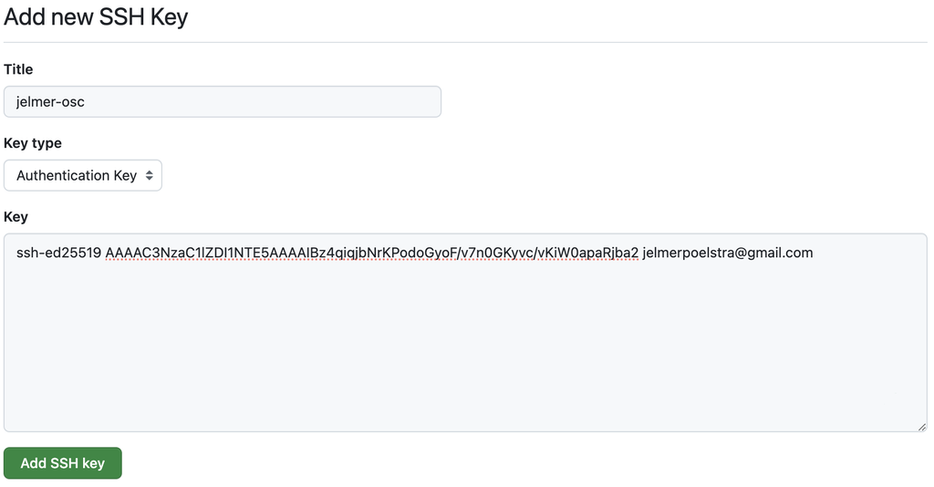

#### Authentication and GitHub URLs

The current two options to authenticate to GitHub when connecting with remotes are:

- `SSH` access with an SSH key (which we have just set up)
- `HTTPS` access with a Public Access Token (PAT)[^3]

These two options are associated with separate URLs for your repos on GitHub. For interacting with your repo on the command line, **you should make sure to select the URL type corresponding to your authorization type**. Since you have set up SSH but not HTTPS authentication, you must use URLs with the SSH format, which look like this:

```
git@github.com:<USERNAME>/<REPOSITORY>.git
```

(HTTPS URLs are in the more familiar-looking format `https://github.com/<USERNAME>/<REPOSITORY>.git`)

We’ll see an example of this in a bit.

### 2.2 Create a remote repository

While we can *interact* with online repos using Git commands, we can’t *create* a new online repo with the Git CLI. Therefore, go to the GitHub website to create a new online repo:

1. On the GitHub website, click the **`+`** next to your avatar (top-right) and select “**New repository**”:

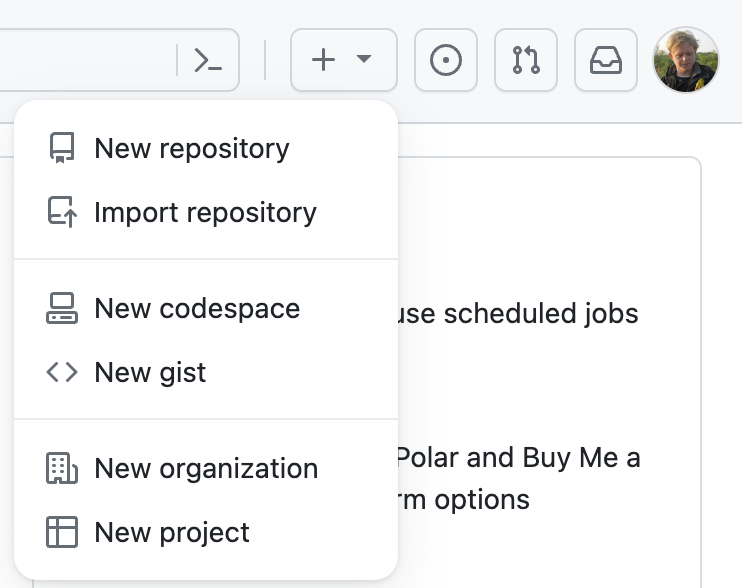

2. In the box “**Repository name**”, use the same name as that of your local dir: `originspecies`(though note that these names don’t *have to* match). You can leave the Description empty in this case.

[figure not shown]

3. Leave other options unchanged, as shown below, and click “**Create repository**”:

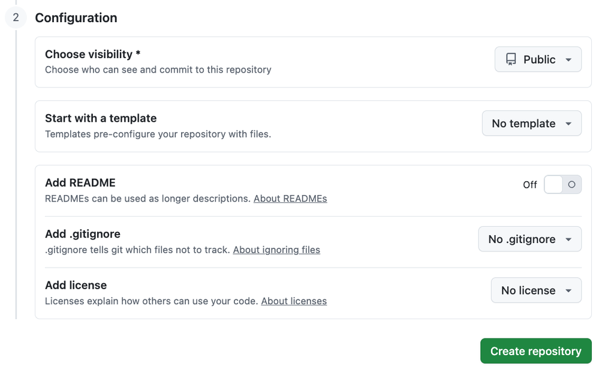

**TipNotes on the above settings**

### 2.3 Link the local and remote repositories

After you clicked “Create repository”, a page similar to this screenshot should appear, which provides information about linking the remote and local repositories:

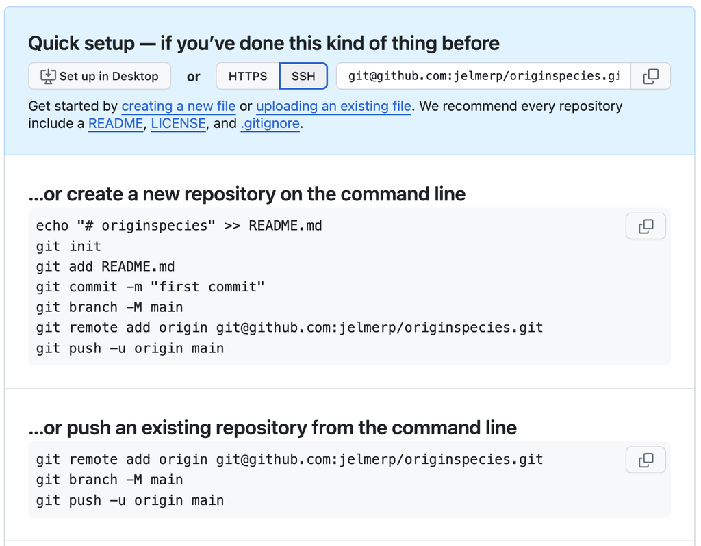

Go back to VS Code to enter the commands that GitHub provided us with under the “*…or push an existing repository from the command line*” heading shown at the bottom of the screenshot above[^4]:

1. First, tell Git to add a “remote” connection with **`git remote`**, providing three arguments to this command:
   - **`add`** — because we’re adding a remote connection
   - **`origin`** — the nickname for the connection (could be anything but is usually called “origin” by convention).
   - The **URL** to the GitHub repo (**in SSH format**: click on the `HTTPS`/`SSH` button to toggle the URL type)

   ```bash
   # git remote add <remote-nickname> <URL>
   git remote add origin git@github.com:<user>/originspecies.git
   ```

2. Second, upload (“push”) your local repo to remote using **`git push`**. Only when you push a repository for the first time, you must use the `-u` option to set up an “**u**pstream” counterpart:

   ```bash
   # git push -u <connection> <branch>
   git push -u origin main
   ```

3. You should get a message like this: type `yes` and press `Enter`.

   ```
   The authenticity of host 'github.com (140.82.114.4)' can't be established.
   ECDSA key fingerprint is SHA256:p2QAMXNIC1TJYWeIOttrVc98/R1BUFWu3/LiyKgUfQM.
   ECDSA key fingerprint is MD5:7b:99:81:1e:4c:91:a5:0d:5a:2e:2e:80:13:3f:24:ca.
   Are you sure you want to continue connecting (yes/no)?
   ```

4. The push/upload should process, with a message along these lines printed:

   ```
   Counting objects: 18, done.
   Delta compression using up to 40 threads.
   Compressing objects: 100% (12/12), done.
   Writing objects: 100% (18/18), 1.67 KiB | 0 bytes/s, done.
   Total 18 (delta 1), reused 0 (delta 0)
   remote: Resolving deltas: 100% (1/1), done.
   remote: To git@github.com:jelmerp/originspecies.git
   * [new branch]      main -> main
   ```

From now on, you can push with a simpler command, because without additional arguments, `git push` will push:

- To the **default remote connection** (which we just set up)
- To and from the **currently active repository *“branch”*** (default: `main` – this is our only branch)[^5].

Therefore, you can simply use the following to push command from now on:

```bash
git push
```

**NoteCheck or change the remote connection**

You can check your remote connection settings for a repo with `git remote -v`:

```bash
git remote -v
```

```
origin  git@github.com:jelmerp/originspecies.git (fetch)
origin  git@github.com:jelmerp/originspecies.git (push)
```

If you need to change the URL of your connection, you can use:

```bash
git remote set-url origin <NEW_URL>
```

### 2.4 Explore the repository on GitHub

Back at GitHub on your repo page, click `<> Code` in the lower of the top bars:

[figure not shown]

This is basically your repo’s “home page”, and you can see the files you just uploaded from your local repo:

[figure not shown]

Next, click on `x commits` (`x` should be 10 if you followed along exactly in the previous class – but it’s not really important if you have a different number):

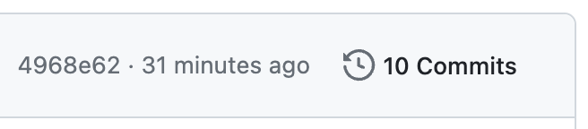

You’ll get an overview of the commits you made, somewhat similar to `git log`’s output:

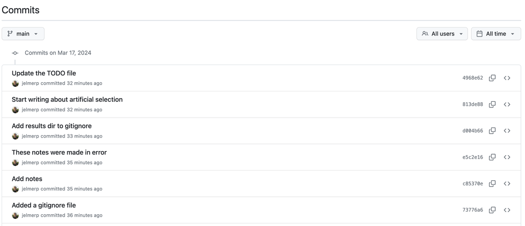

You can click on a commit message to see the changes made by that commit:

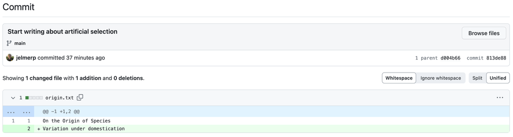

The line that is highlighted in green was added by this commit.

Go back to the previous page, the overview of commits. On the right-hand side, a **`< >`** button will allow you to see the *state of the entire repo* (all files in the project) at the time of that commit:

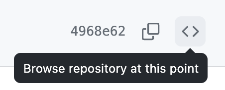

On the commit overview page, scroll down all the way to the first commit and click the **`< >`**: you’ll see the repo’s “home page” again, but now with only the `origin.txt` file, since that was the only file in your repo at the time:

[figure not shown]

#### GitHub “Issues”

Each GitHub repository has an “Issues” tab. GitHub Issues are mainly used to track bugs and other (potential) problems with a repository. In an issue, you can reference specific commits and people, and use Markdown formatting.

For future assignments and your final project, you will create an issue simply to notify me about your repository.

To go to the Issues tab for your repo, click on Issues towards the top of the page:

[figure not shown]

And you should see the following page — in which you can open a new issue with the “New Issue” button:

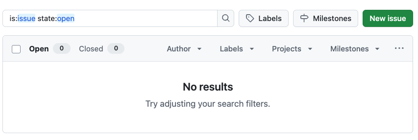

## 3 Remote repo workflows: single-user

Here we will go over the typical Git + GitHub workflow with a single user, i.e., without someone collaboratoring with you on the repository. The version control bonus page covers collaboration with Git and Github, i.e. multi-user workflows.

In a single-user workflow, all changes are typically made in the local repository, and the remote repo is simply periodically updated (*pushed to*). So, the interaction between local and remote is unidirectional:

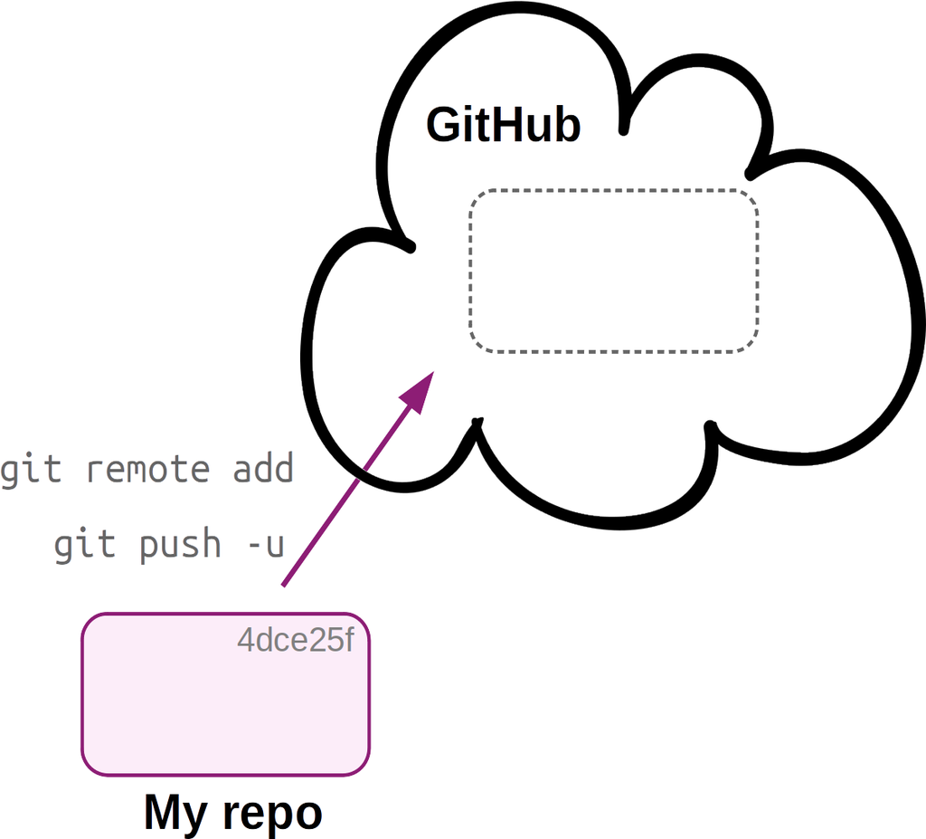

**A**  
When pushing to remote for the first time, you first set up the connection with `git remote` and use the `u` option to `git push`.

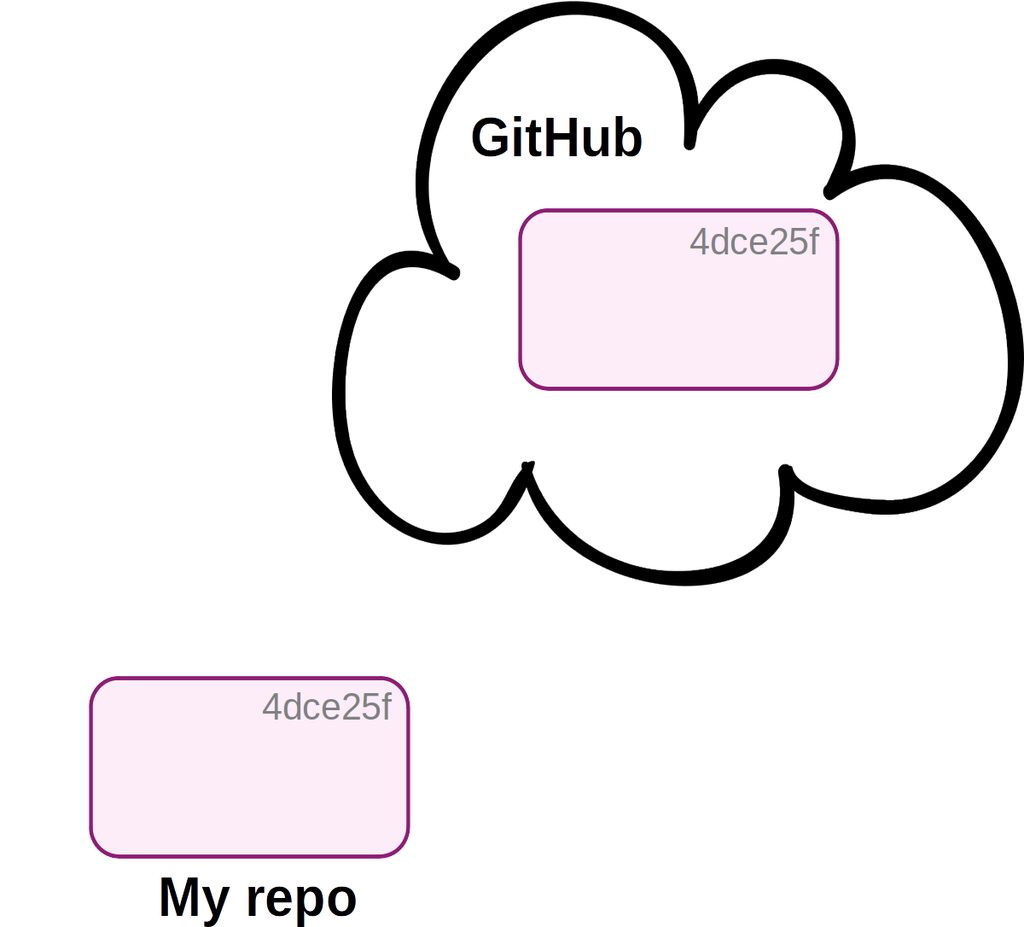

**B**  
Now, the local (“My repo”) and remote (“GitHub”) are in sync.

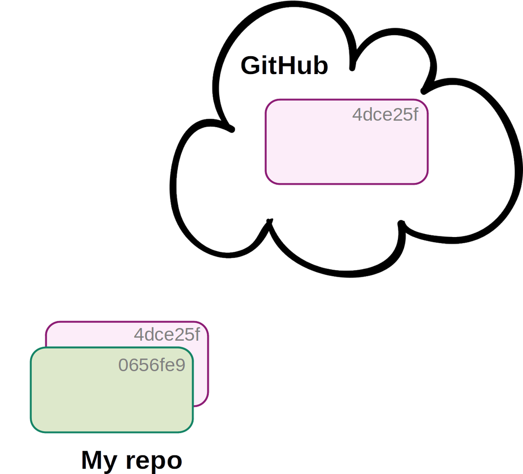

**C**  
Next, you’ve made a new commit locally: the local and remote are out of sync.

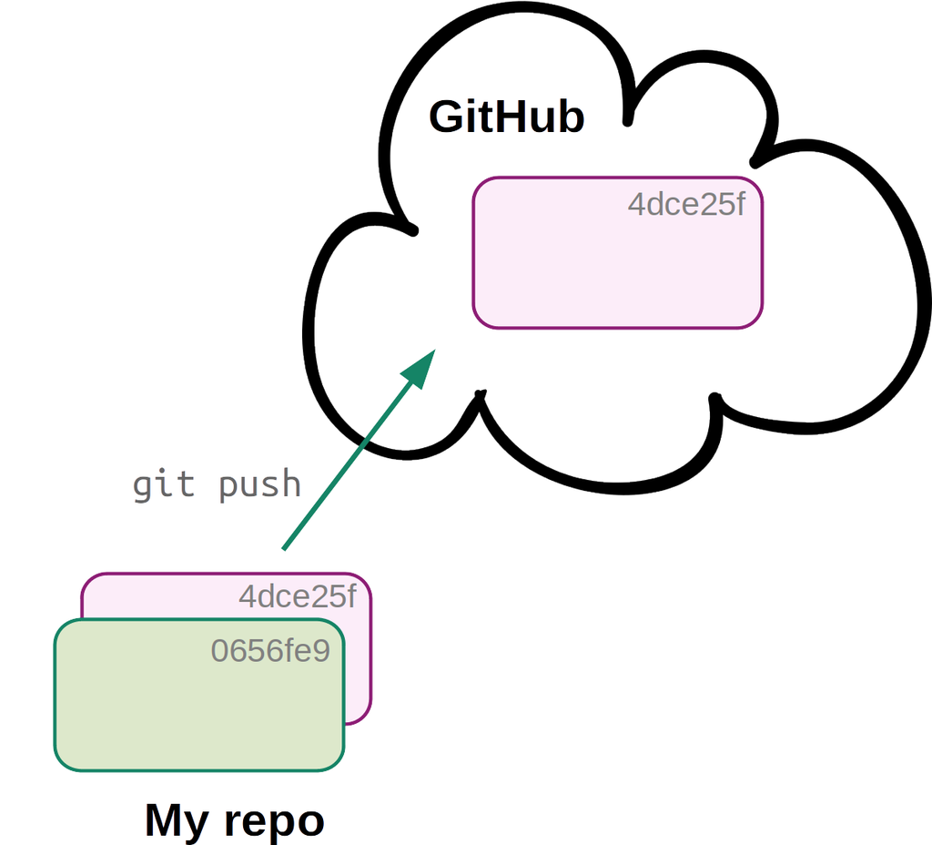

**D**  
You simply use `git push` to update the remote, after which the local and remote will be back in sync (latter not shown).

In a single-user workflow with a remote, you commit just like you would without a remote in your day-to-day work, and in addition, *push* to remote occasionally. Let’s run through an example.

- Start by creating a `README.md` file for your repo:

  ```bash
  echo "# Origin" > README.md
  echo "Repo for book draft on my new **theory**" >> README.md
  ```

- Add and commit the file:

  ```bash
  git add README.md
  git commit -m "Added a README file"
  ```

  ```
  [main 63ce484] Added a README file
  1 file changed, 2 insertions(+)
  create mode 100644 README.md
  ```

- If you now run `git status`, you’ll see that Git knows that your local repo is now one commit “ahead” of its remote counterpart:

  ```
  On branch main
  Your branch is ahead of 'origin/main' by 1 commit.
  (use "git push" to publish your local commits)

  nothing to commit, working tree clean
  ```

- But Git will not automatically sync! So, now push to the remote repository:

  ```bash
  git push
  ```

Let’s go back to GitHub: note that the `README.md` Markdown has been automatically rendered!

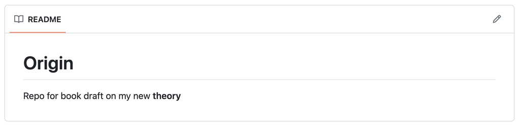

## 4 Git and GitHub recap

A single-user Git workflow, with a GitHub remote, consists at its core of the following order of steps/commands:

1. Work on your research and change files in the repo
2. Stage changes with `git add`
3. Commit changes with `git commit`
4. Push commits with `git push`

Additional Git functionality we have seen:

1. Add untracked files to the repo -also- with `git add`
2. Make sure Git ignores files with a `.gitignore` file
3. Check the current status of your repo with `git status` – e.g. what files have changed since your last commit
4. See the specific changes you have made to files with `git diff` (or with VS Code’s “Source Control” panel)
5. Get an overview of your past commits with `git log`
6. Set up and manage the connection to a remote on GitHub with `git remote`

Back to top

## Footnotes

[^1]: Or use the keyboard shortcut `Ctrl`+`` ` ``.
[^2]: We will not cover collaboration workflows in class, though – see the bonus material for this.
[^3]: [See this GitHub page](https://docs.github.com/en/authentication/keeping-your-account-and-data-secure/managing-your-personal-access-tokens) to set this up instead of or in addition to SSH access.
[^4]: Though we can skip the second one, `git branch -M main`, since our branch is already called “main”.
[^5]: To learn more about branches, see the Git bonus material.